# From Surveys to Populations

GVPT399F: Power, Politics, and Data

## Surveys

- Populations are very difficult to collect data on
  - Even the census misses people!
- Happily, we can use surveys of a sample of our population to learn things about our population
- However, our ability to do this is conditional on how good our sample is
- What do I mean by “good”?

## The 2024 US Presidential Election

- Elections are preceded by a flood of surveys

## Surveys

- Surveys are conducted on a subset (**sample**) of the population of interest
- Our population of interest: individuals who voted in the 2024 US Presidential Election

## A good sample

- A good sample is a **representative one**
- How closely does our sample reflect our population

## Parallel worlds

- Remember back to last session on experiments
- In an ideal world, we would be able to create two parallel worlds (one with the treatment, one held as our control)
  - One version of the election booth run without monitors (the control)
  - One version with monitors (the treatment)
- These worlds are perfectly identical to each other prior to treatment
- We cannot do this :(

## The next best thing

- Our next best option is to create two groups that were as identical to one another as possible prior to treatment
- If they are (almost) identical, differences between their group-wide outcomes can be attributed to the treatment
- One good way of getting two (almost) identical groups is to assign individuals to those groups **randomly**
  - Think back to our 1,000 hypothetical people!

## Randomization

- Randomization continues to pop its chaotic head up
- We can use it to create a sample that is (almost) identical to our population, on average
- Drawing randomly from our population increases our chances of ending up with a sample that reflects that population
- This would be referred to as a **representative sample**

## Random sampling

- All individuals in the population need to have an equal chance of being selected for the sample
  - If this holds, you have a **pure random sample**
- This is really hard to do!
  - How likely were you to answer the pollster’s unknown number, calling you in the middle of the day?
  - Even if you did answer, how likely were you to answer all their questions?

## To illustrate

Countries’ GDP in 2022:

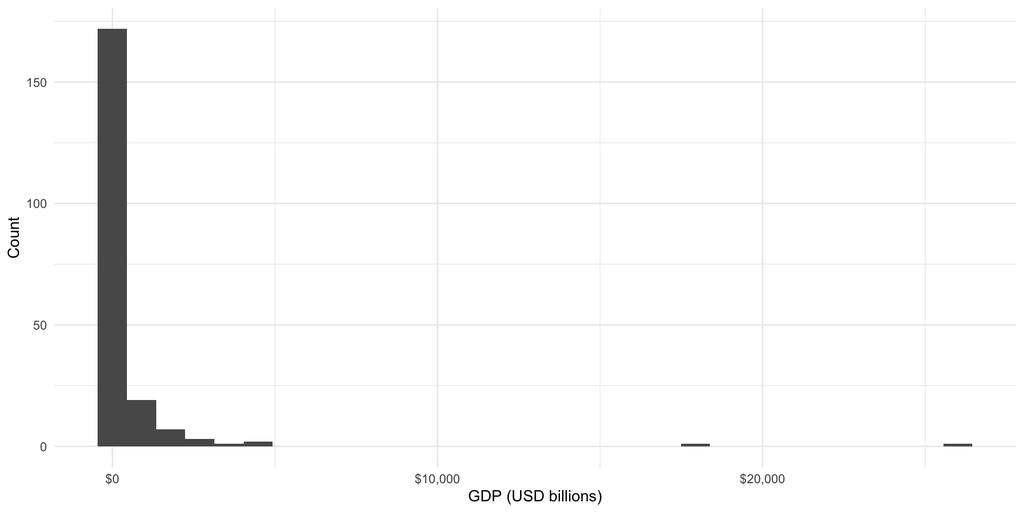

## Countries’ GDP

I want to estimate the average GDP across all countries in 2022.

- I send out a survey to all countries’ Departments of Statistics and ask for their GDP figures for 2022.
- I get 60 responses:

```r
sample_df <- gdp_df |>
  drop_na(sample_value) |>
  sample_n(size = 60) |>
  transmute(country, gdp = sample_value)

sample_df
```

```
# A tibble: 60 × 2
   country                    gdp
   <chr>                    <dbl>
 1 Costa Rica        69243626029.
 2 Oman             111943823147.
 3 Slovak Republic  115928615553.
 4 Papua New Guinea  31647277767.
 5 Finland          280241515774.
 6 Hungary          177006128625.
 7 Latvia            38018905782.
 8 Ghana             74263364042.
 9 Guatemala         95630524813.
10 Belgium          593438820508.
# ℹ 50 more rows
```

## Countries’ GDP

I now calculate the average of these responses, which I find to be:

```r
sample_df |>
  summarise(avg_gdp = scales::dollar(mean(gdp, na.rm = T)))
```

```
# A tibble: 1 × 1
  avg_gdp
  <chr>
1 $885,340,520,391
```

## Non-response bias

Poorer countries are far less likely to be able or willing to provide these economic data to academics or international organizations.

- They tend to be underrepresented in a lot of data

My sample was biased against poorer countries.

- They were not equally likely to respond to my request for data as rich countries

## Large numbers

- Randomization isn’t enough: we also need to draw a sufficiently large sample from our population
  - One person pulled randomly from the class isn’t going to be very reflective of the class!